# Homework 3

Yan Wang (yw2668)

October 23, 2014

## Acquire and familiarize yourself with the data

#### A. Identify two surveys that you want to compare.

I would like to choose two waves from World Value Survey. Because the countries under study in the first two waves are very limited, I choose Wave 3 and Wave 6 for this study.

#### B. Sketch and/or describe the graph(s) that you intend to make; these amount to informal research hypotheses.

I choose the variable “V10” of each survey, which investigates people’s feeling of happiness. I plan to compare the happiness index of different countries/continents in those two waves. I expect that on average the happiness index has increased over years in most countries/continents. Now let’s see if the result fits my expectation.

#### C. Write down the target shape of the data

Country: “China, United State, Japan, South Korea…” value：“0.42, 0.41, 0.56, 0.98…” Wave: “wave_3, wave_6” Continent: “Asia, North America…”

## Write code to analyze and visualize it

#### D. Write a script that reads, transforms, prepares data for your graph.

```r
#Read R Data into the project
setwd("/Users/Emily/Documents/Columbia/Data Visualization/Homework 3")
load("WV3_Data_rdata_v_2014_09_21.rdata")
d1<- WV3_Data_rdata_v_2014_09_21
load("WV6_Data_rdata_v_2014_06_04.rdata")
d2<-WV6_Data_spss_v_2014_06_04

#Check the variables I intend to look into

str(d1$V2)
```

```
##  int [1:76075] 8 8 8 8 8 8 8 8 8 8 ...
```

```r
table(d1$V2)
```

```
##
##    8   31   32   36   50   51  100  112  152  156  158  170  191  203  214
##  999 2002 1079 2048 1525 2000 1072 2092 1000 1500  780 6025 1196 1147  417
##  222  233  246  268  276  348  356  410  428  440  484  498  554  566  578
## 1254 1021  987 2008 2026  650 2040 1249 1200 1009 2364  984 1201 1996 1127
##  586  604  608  616  630  642  643  703  705  710  724  752  756  792  804
##  733 1211 1200 1153 1164 1239 2040 1095 1007 2935 1211 1009 1212 1907 2811
##  807  826  840  858  862  911  912  914
##  995 1093 1542 1000 1200 1280  240  800
```

```r
sum(is.na(d1$V2))
```

```
## [1] 0
```

```r
str(d1$V10)
```

```
##  int [1:76075] 3 2 3 3 3 3 3 3 3 2 ...
```

```r
table(d1$V10)
```

```
##
##    -4    -2    -1     1     2     3     4
##  3029    30   880 17399 37447 14855  2435
```

```r
sum(is.na(d1$V10))
```

```
## [1] 0
```

```r
str(d2$V2)
```

```
##  int [1:74042] 12 12 12 12 12 12 12 12 12 12 ...
```

```r
table(d2$V2)
```

```
##
##   12   31   36   51  112  152  156  158  170  196  218  233  275  276  288
## 1200 1002 1477 1100 1535 1000 2300 1238 1512 1000 1202 1533 1000 2046 1552
##  368  392  398  400  410  414  417  422  434  458  484  504  528  554  566
## 1200 2443 1500 1200 1200 1303 1500 1200 2131 1300 2000 1200 1902  841 1759
##  586  604  608  616  634  642  643  646  702  705  716  724  752  780  788
## 1200 1210 1200  966 1060 1503 2500 1527 1972 1069 1500 1189 1206  999 1205
##  792  804  818  840  858  860  887
## 1605 1500 1523 2232 1000 1500 1000
```

```r
sum(is.na(d2$V2))
```

```
## [1] 0
```

```r
str(d2$V10)
```

```
##  int [1:74042] 2 2 2 2 1 2 2 2 2 1 ...
```

```r
table(d2$V10)
```

```
##
##    -5    -2    -1     1     2     3     4
##     4   228   464 23873 38105  9290  2078
```

```r
sum(is.na(d2$V10))
```

```
## [1] 0
```

```r
#Check out the labels of each variable
lapply(attributes(d1), length)
```

```
## $names
## [1] 281
##
## $val.labels
## [1] 281
##
## $var.labels
## [1] 281
##
## $row.names
## [1] 76075
##
## $class
## [1] 1
##
## $label.table
## [1] 281
```

```r
names(attr(d1,'var.labels')[[12]])
```

```r
attr(d1,'label.table')[[12]]
```

```
##      Not asked             na             dk     very happy    quite happy
##             -4             -2             -1              1              2
## not very happy       notatall
##              3              4
```

```r
table(d1$V10)
```

```
##
##    -4    -2    -1     1     2     3     4
##  3029    30   880 17399 37447 14855  2435
```

```r
lapply(attributes(d2), length)
```

```
## $names
## [1] 381
##
## $val.labels
## [1] 381
##
## $var.labels
## [1] 381
##
## $row.names
## [1] 74042
##
## $class
## [1] 1
##
## $label.table
## [1] 381
```

```r
names(attr(d2,'var.labels')[[11]])
```

```r
attr(d2,'label.table')[[11]]
```

```
## RU: Inappropriate response{Inappropriate}
##                                        -5
##                       Not asked in survey
##                                        -4
##                            Not applicable
##                                        -3
##                                 No answer
##                                        -2
##                                Don´t know
##                                        -1
##                                Very happy
##                                         1
##                              Rather happy
##                                         2
##                            Not very happy
##                                         3
##                          Not at all happy
##                                         4
```

```r
table(d2$V10)
```

```
##
##    -5    -2    -1     1     2     3     4
##     4   228   464 23873 38105  9290  2078
```

```r
##Make the value of "very happy" or "rather happy" equals to 1, and the value of "not quite happy" or "not at all happy" equals to 0. Other answers are omitted.
d3<-subset(d1, V10>0, select=c(V2, V10))
d6<-subset(d2, V10>0, select=c(V2, V10))
d3$V10[d3$V10 <= 2] <- 1
d3$V10[d3$V10 >= 2] <- 0
d6$V10[d6$V10 <= 2] <- 1
d6$V10[d6$V10 >= 2] <- 0
```

```r
#Calculate the mean of "Happiness" of each country for the two waves and then merge the resultant datasets
library(plyr)
d3_mean<-ddply(d3, .(V2), summarise, mean=mean(V10,na.rm=TRUE))
colnames(d3_mean) <- c("Country", "Happiness")
country3<-attr(d1, 'label.table')[[2]]
d3_mean$Country <- names(country3)[match(d3_mean$Country, country3)]
d6_mean<-ddply(d6, .(V2), summarise, mean=mean(V10,na.rm=TRUE))
colnames(d6_mean) <- c("Country", "Happiness")
country6<-attr(d2, 'label.table')[[2]]
d6_mean$Country <- names(country6)[match(d6_mean$Country, country6)]
happy<-merge(d3_mean, d6_mean, by="Country")
colnames(happy) <- c("Country", "Wave 3", "Wave 5")
```

```r
#Continue to tidy data
library(rworldmap)
temp_map = getMap(resolution='coarse')
continent<-temp_map@data[c('NAME','REGION')]
colnames(continent)<-c("Country","Continent")
all(happy$Country %in% continent$Country)
```

```
## [1] FALSE
```

```r
which(happy$Country %in% continent$Country, arr.ind =TRUE)
```

```
##  [1]  1  2  3  4  5  6  7  8  9 10 11 12 13 14 15 16 17 18 19 21 22 23 24
## [24] 25 26 27
```

```r
happy$Country[[20]]<-"S. Korea"
all(happy$Country %in% continent$Country)
```

```
## [1] TRUE
```

```r
happy<-merge(happy, continent, by="Country")
library(reshape2)
happym<-melt(happy, id =c("Country","Continent"))
colnames(happym)[c(3,4)]<-c("Wave","Happiness")
happy_con<-dcast(happym,Wave~Continent, mean,na.rm=T)
happy_con<-melt(happy_con, id =c("Wave"))
happy_con["value"]<-round(happy_con["value"], digits=3)
```

#### E. Make it actually make your graph.

```
## ymax not defined: adjusting position using y instead
```

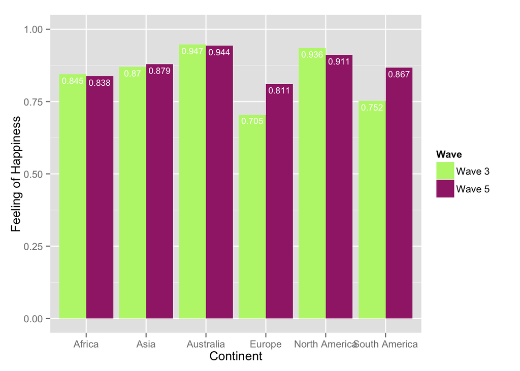

```r
#Bar Chart
library(ggplot2)
ggplot(happy_con,aes(x=variable, y=value,fill=Wave))+geom_bar(stat="identity",position="dodge")+geom_text(aes(label=value),vjust=1.5, colour="white", position=position_dodge(.9),size=3)+ylim(0,1)+xlab("Continent")+ylab("Feeling of Happiness")+scale_fill_manual(values=c("#BAF479","#A02A77"))
```

```r
#Maps
library(RColorBrewer)
library("sp")

datalist<-list(d3_mean,d6_mean)
titlelist<-c("Feeling of Happiness (1995-1999)", "Feeling of Happiness (2010-2014)")
par(fin=c(7,9),mfcol=c(1,2),mai=c(0,0,0.2,0),xaxs="i",yaxs="i")
```

```r
# This function works in R console and returns two maps aligned to show different levels of happiness in two waves.
# But it seems that Rmarkdown can't knit "sPDF@data", therefore can't display properly. I will try to push the pic seperately and try to work out a solution later.
for(i in 1:2){
 data<-datalist[[i]]
sPDF<-joinCountryData2Map(data, joinCode = "NAME", nameJoinColumn = "Country", verbose = F)
sPDF@data[["Happy.Cat"]] <- cut(sPDF@data[["Happy"]], breaks=c(0.3,0.4,0.5,0.6,0.7,0.8,0.9,1.0), )
levels(sPDF@data[["Happy.Cat"]]) <- c("very low", "low","a bit low","medium","a bit high", "high", "very high")
mapParams<-mapCountryData(sPDF, nameColumnToPlot="Happy.Cat", catMethod="categorical", mapTitle=titlelist[i], colourPalette=brewer.pal(7, "RdPu"), oceanCol="lightblue", missingCountryCol="white")
                          }
```

[output not shown]

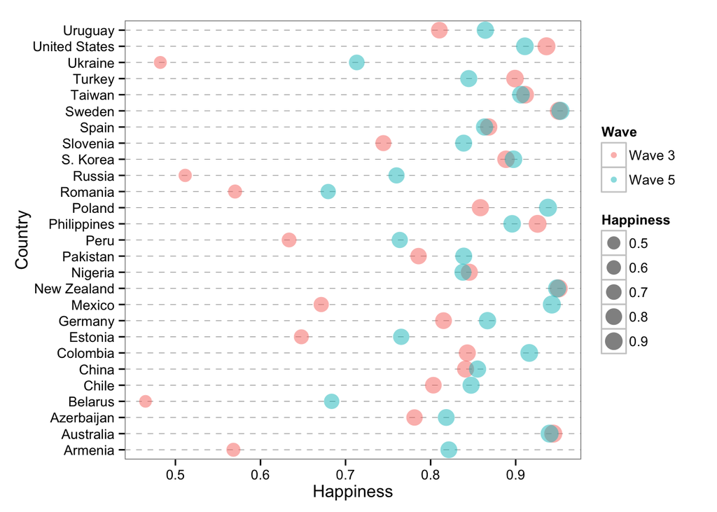

```r
#Scatter Plot
ggplot(happym,aes(x=Happiness,y=Country, size=Happiness,colour=Wave))+geom_point(alpha=.5)+theme_bw()+theme(panel.grid.major.x=element_blank(), panel.grid.minor.x=element_blank(), panel.grid.major.y=element_line(colour="grey60", linetype="dashed"))+scale_size_area()+scale_fill_manual(values=c("#84DB61","#A02A77"))
```

#### F. Write expressive fantasy function calls that describe how you read, transformed, and prepared the data for the graph.

```r
survey1 <- loadSurvey(1)
survey1 <- selectVariables(survey1, ...)
survey1 <- checkVariables(suvey1,...)
survey1 <- handleMissingData(survey1, ...)
survey1 <- labelValues(survey1)
summarize1 <- summarizeVariables(survey1, ...) #get interested descriptive statistics
plotData <- preparePlotData(summarize1, ...)

survey2 <- loadSurvey(2)
survey2 <- selectVariables(survey2, ...)
survey2 <- checkVariables(suvey2,...)
survey2 <- handleMissingData(survey2, ...)
survey2 <- labelValues(survey2)
summarize2 <- summarizeVariables(survey2, ...) #get interested descriptive statistics
plotData <- preparePlotData(summarize2, ...)

CombineData <- merge(survey1, survey2...)
meltData <- TidyData(CombineData,...) #transform data to favorable format
castData <- GetPerfectData(...)
ggplot(, aes(...)) + ...
joinCountryData2Map(,...
mapCountryData(,...
```

#### G. (Bonus) Write (some or all of) the functions to read, transform, and analyze the data.

```r
#If I need to compare more than 2 datasets, then it will much more convient to use functions
surveylist <- list(survey1, survey2, survey3...)

#Function Example 1 : Congregate Data
WholeData<- for (i in 1:length(surveylist))
  {
  transform1 <- ddply(surveylist(1), .(variable), summarise, FUN)
  transform <- ddply(surveylist(i), .(variable), summarise, FUN)
  if(i==1) {
    merge<-merge(transform1,transform, by=)
    else
      merge<- merge(merge,transform, by=)
  }

}

#Function Example 2 : Draw Maps for Each Dataset
titlelist<- list(title1, title2, title3...)
for(i in 1:length(surveylist))
  {
 survey<-surveylist[[i]]
sPDF<-joinCountryData2Map(survey, joinCode = "NAME", nameJoinColumn = "Country", verbose = F)
sPDF@data[["Variable.Cat"]] <- cut(sPDF@data[["Variable"]], breaks=c(), )
levels(sPDF@data[["Varible.Cat"]]) <- c()
mapParams<-mapCountryData(sPDF, nameColumnToPlot="Variable.Cat", catMethod="categorical", mapTitle=titlelist[i], colourPalette=brewer.pal(7, "RdPu"), oceanCol="lightblue", missingCountryCol="white")
}
```

#### Conclusion:

The graphics show that today happiness index has slightly increased compared to that of 90s in most countries, which is in line with my expection.